# TP 3 unmarked

Olivier Gimenez

19/12/2020

# Partie 1

## 1. Introduction

On charge le package `unmarked`.

```r
library(unmarked)
```

## 2. Les données

On lit les données lézard ocelés.

```r
dat <- read.csv2("dat/lezard-ocelle-oleron-2007-pa.csv")
```

Jette un coup d’oeil.

```r
head(dat)
```

```
##   site presence_R1 presence_R2 presence_R3 Abond_R1 Abond_R2 Abond_R3 temp_R1
## 1    1           1           1           1        0        2        0    21.2
## 2    2           1           1           1        1        2        5    21.7
## 3    3           0           1           1        0        3        1    22.7
## 4    4           1           1           1        0        1        2    23.5
## 5    5           1           1           1        1        2        2    24.2
## 6    6           1           1           1        1        1        3    23.9
##   temp_R2 temp_R3 vent_R1 vent_R2 vent_R3 nuage_R1 nuage_R2 nuage_R3
## 1    24.8    21.6     2.7     5.7     3.3        1        1        2
## 2    23.8    23.8     2.2     4.7     2.6        1        2        1
## 3    22.5    24.2     0.8     2.5     7.2        1        2        3
## 4    22.4    18.3     2.4     1.4     1.3        1        2        3
## 5    24.8    20.1     3.4     2.2     3.3        1        2        3
## 6    26.3    23.9     2.7     2.2     6.7        1        2        4
##   nb_terriers_lapins
## 1                  0
## 2                  5
## 3                  1
## 4                  2
## 5                  5
## 6                 10
```

Dimensions.

```r
dim(dat)
```

```
## [1] 70 17
```

On crée le jeu de données.

```r
lezard <- unmarkedFrameOccu(y = cbind(dat$presence_R1, dat$presence_R2, dat$presence_R3))
```

Coup d’oeil.

```r
head(lezard)
```

```
## Data frame representation of unmarkedFrame object.
##    y.1 y.2 y.3
## 1    1   1   1
## 2    1   1   1
## 3    0   1   1
## 4    1   1   1
## 5    1   1   1
## 6    1   1   1
## 7    1   1   1
## 8    0   1   1
## 9    0   0   0
## 10   1   1   1
```

Coup d’oeil.

```r
summary(lezard)
```

```
## unmarkedFrame Object
##
## 70 sites
## Maximum number of observations per site: 3
## Mean number of observations per site: 3
## Sites with at least one detection: 53
##
## Tabulation of y observations:
##   0   1
##  82 128
```

Coup d’oeil.

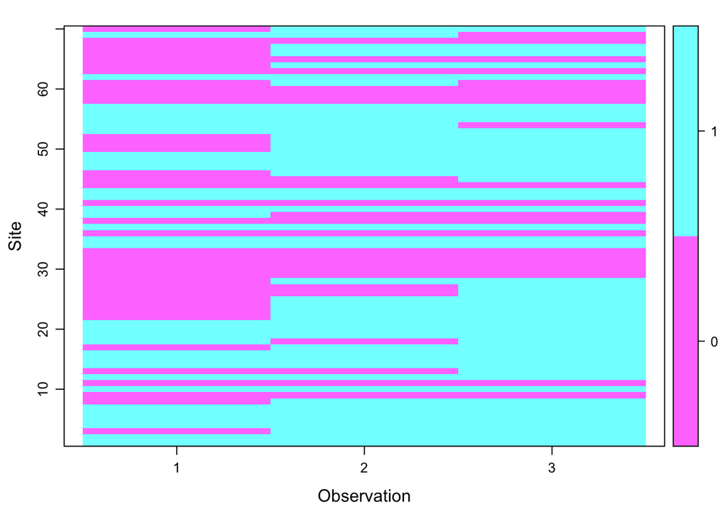

```r
plot(lezard)
```

## 3. Modèle $(\psi, p)$

Aide de la fonction `occu`.

```r
?occu
```

Ajuste premier modèle, avec détection d’abord, puis occupancy. Ici ces paramètres sont constants.

```r
fm <- occu(~ 1 ~ 1, lezard)
```

Les estimations sont sur échelle logit.

```r
fm
```

```
##
## Call:
## occu(formula = ~1 ~ 1, data = lezard)
##
## Occupancy:
##  Estimate    SE    z  P(>|z|)
##      1.17 0.287 4.09 4.37e-05
##
## Detection:
##  Estimate    SE    z  P(>|z|)
##      1.38 0.207 6.64 3.13e-11
##
## AIC: 237.6654
```

On les back-transforme.

```r
#names(fm)
#fm['state']
#fm['det']
backTransform(fm, type ='state')
```

```
## Backtransformed linear combination(s) of Occupancy estimate(s)
##
##  Estimate     SE LinComb (Intercept)
##     0.763 0.0518    1.17           1
##
## Transformation: logistic
```

```r
backTransform(fm, type ='det')
```

```
## Backtransformed linear combination(s) of Detection estimate(s)
##
##  Estimate     SE LinComb (Intercept)
##     0.798 0.0334    1.38           1
##
## Transformation: logistic
```

```r
confint(backTransform(fm, type='state'))
```

```
##     0.025     0.975
##  0.647844 0.8498077
```

```r
confint(backTransform(fm, type='det'))
```

```
##      0.025     0.975
##  0.7251664 0.8560502
```

Conditional occupancy.

```r
re <- ranef(fm)
re
```

```
##             Mean Mode 2.5% 97.5%
##  [1,] 1.00000000    1    1     1
##  [2,] 1.00000000    1    1     1
##  [3,] 1.00000000    1    1     1
##  [4,] 1.00000000    1    1     1
##  [5,] 1.00000000    1    1     1
##  [6,] 1.00000000    1    1     1
##  [7,] 1.00000000    1    1     1
##  [8,] 1.00000000    1    1     1
##  [9,] 0.02574042    0    0     1
## [10,] 1.00000000    1    1     1
## [11,] 0.02574042    0    0     1
## [12,] 1.00000000    1    1     1
## [13,] 1.00000000    1    1     1
## [14,] 1.00000000    1    1     1
```

[output cut: 56 more lines]

## 4. Modèle $(\psi, p_t)$

On crée un variable pour l’effet du temps.

```r
occ <- matrix(c('occ 1','occ 2','occ 3'),
              nrow = 70, # nrow(lezard@y),
              ncol = 3, #ncol(lezard),
              byrow = TRUE)
```

On refait le jeu de données.

```r
lezard <- unmarkedFrameOccu(y = cbind(dat$presence_R1, dat$presence_R2, dat$presence_R3),
                            obsCovs = list(occ = occ))
```

Données?

```r
summary(lezard)
```

```
## unmarkedFrame Object
##
## 70 sites
## Maximum number of observations per site: 3
## Mean number of observations per site: 3
## Sites with at least one detection: 53
##
## Tabulation of y observations:
##   0   1
##  82 128
##
## Observation-level covariates:
##     occ
##  occ 1:70
##  occ 2:70
##  occ 3:70
```

Ajuste modèle.

```r
fm1 <- occu(~ occ ~ 1, lezard)
```

Les estimations sont sur échelle logit.

```r
fm1
```

```
##
## Call:
## occu(formula = ~occ ~ 1, data = lezard)
##
## Occupancy:
##  Estimate    SE    z  P(>|z|)
##      1.15 0.282 4.08 4.43e-05
##
## Detection:
##             Estimate    SE    z  P(>|z|)
## (Intercept)    0.412 0.281 1.47 0.142514
## occocc 2       1.615 0.514 3.14 0.001672
## occocc 3       2.046 0.587 3.48 0.000495
##
## AIC: 222.2077
```

On back-transforme l’occupancy.

```r
backTransform(fm1, type = 'state')
```

```
## Backtransformed linear combination(s) of Occupancy estimate(s)
##
##  Estimate     SE LinComb (Intercept)
##      0.76 0.0515    1.15           1
##
## Transformation: logistic
```

```r
confint(backTransform(fm1, type='state'))
```

```
##      0.025    0.975
##  0.6454809 0.846208
```

Et pour la détection.

```r
nd <- data.frame(occ = c('occ 1','occ 2','occ 3'))
predict(fm1, type = 'det', newdata = nd)
```

```
##   Predicted         SE     lower     upper
## 1 0.6015503 0.06732683 0.4654020 0.7236164
## 2 0.8835590 0.04463644 0.7642686 0.9466936
## 3 0.9211504 0.03779961 0.8081554 0.9700580
```

Conditional occupancy.

```r
ranef(fm1)
```

```
##            Mean Mode 2.5% 97.5%
##  [1,] 1.0000000    1    1     1
##  [2,] 1.0000000    1    1     1
##  [3,] 1.0000000    1    1     1
##  [4,] 1.0000000    1    1     1
##  [5,] 1.0000000    1    1     1
##  [6,] 1.0000000    1    1     1
##  [7,] 1.0000000    1    1     1
##  [8,] 1.0000000    1    1     1
##  [9,] 0.0114465    0    0     0
## [10,] 1.0000000    1    1     1
## [11,] 0.0114465    0    0     0
## [12,] 1.0000000    1    1     1
## [13,] 1.0000000    1    1     1
## [14,] 1.0000000    1    1     1
```

[output cut: 56 more lines]

## 5. Modèle $(\psi_{\mbox{lapin}}, p)$

On récupère la variable lapin.

```r
site.covs <- data.frame(lapin = dat$nb_terriers_lapins)
site.covs
```

```
##    lapin
## 1      0
## 2      5
## 3      1
## 4      2
## 5      5
## 6     10
## 7      0
## 8      0
## 9      0
## 10     5
## 11     0
## 12    20
## 13     0
## 14     0
```

[output cut: 56 more lines]

On refait le jeu de données.

```r
lezard <- unmarkedFrameOccu(y = cbind(dat$presence_R1, dat$presence_R2, dat$presence_R3),
                            siteCovs = site.covs)
```

Données?

```r
summary(lezard)
```

```
## unmarkedFrame Object
##
## 70 sites
## Maximum number of observations per site: 3
## Mean number of observations per site: 3
## Sites with at least one detection: 53
##
## Tabulation of y observations:
##   0   1
##  82 128
##
## Site-level covariates:
##      lapin
##  Min.   : 0.000
##  1st Qu.: 0.000
##  Median : 0.000
##  Mean   : 1.643
##  3rd Qu.: 1.000
##  Max.   :20.000
```

Ajuste modèle.

```r
fm2 <- occu(~ 1 ~ lapin, lezard)
```

Les estimations sont sur échelle logit.

```r
fm2
```

```
##
## Call:
## occu(formula = ~1 ~ lapin, data = lezard)
##
## Occupancy:
##             Estimate    SE    z P(>|z|)
## (Intercept)    0.833 0.314 2.65 0.00803
## lapin          1.113 0.893 1.25 0.21297
##
## Detection:
##  Estimate    SE   z  P(>|z|)
##      1.29 0.199 6.5 8.11e-11
##
## AIC: 237.528
```

On back-transforme la détection.

```r
backTransform(fm2, type = 'det')
```

```
## Backtransformed linear combination(s) of Detection estimate(s)
##
##  Estimate     SE LinComb (Intercept)
##     0.784 0.0336    1.29           1
##
## Transformation: logistic
```

```r
confint(backTransform(fm2, type='det'))
```

```
##      0.025     0.975
##  0.7112384 0.8428953
```

Et pour l’occupancy.

```r
nd <- data.frame(lapin = seq(min(dat$nb_terriers_lapins), max(dat$nb_terriers_lapins), length = 50))
psi_pred <- predict(fm2, type = 'state', newdata = nd)
psi_pred
```

```
##    Predicted           SE        lower     upper
## 1  0.6970174 6.636942e-02 5.540805e-01 0.8098596
## 2  0.7836811 7.266438e-02 6.099588e-01 0.8935339
## 3  0.8508600 9.278133e-02 5.764772e-01 0.9598593
## 4  0.8998425 9.670554e-02 5.230901e-01 0.9865936
## 5  0.9339857 8.793310e-02 4.636466e-01 0.9957001
## 6  0.9570453 7.333818e-02 4.030423e-01 0.9986418
## 7  0.9722888 5.776786e-02 3.442402e-01 0.9995738
## 8  0.9822233 4.374697e-02 2.893231e-01 0.9998667
## 9  0.9886379 3.221259e-02 2.396697e-01 0.9999584
## 10 0.9927549 2.323522e-02 1.960183e-01 0.9999870
## 11 0.9953871 1.650034e-02 1.585596e-01 0.9999960
## 12 0.9970658 1.157644e-02 1.270678e-01 0.9999987
## 13 0.9981348 8.043888e-03 1.010429e-01 0.9999996
## 14 0.9988147 5.545562e-03 7.983801e-02 0.9999999
```

[output cut: 36 more lines]

Visualise.

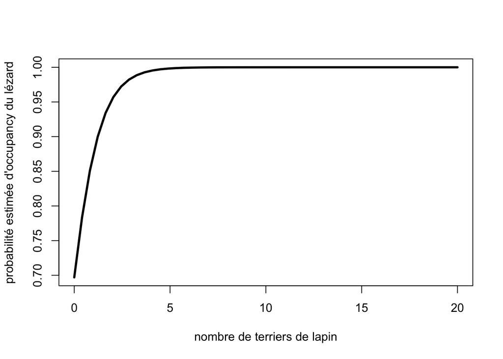

```r
plot(nd$lapin,
     psi_pred[,1],
     type = "l",
     lwd = 3,
     xlab = "nombre de terriers de lapin",
     ylab = "probabilité estimée d'occupancy du lézard")
```

Conditional occupancy.

```r
ranef(fm2)
```

```
##             Mean Mode 2.5% 97.5%
##  [1,] 1.00000000    1    1     1
##  [2,] 1.00000000    1    1     1
##  [3,] 1.00000000    1    1     1
##  [4,] 1.00000000    1    1     1
##  [5,] 1.00000000    1    1     1
##  [6,] 1.00000000    1    1     1
##  [7,] 1.00000000    1    1     1
##  [8,] 1.00000000    1    1     1
##  [9,] 0.02257866    0    0     0
## [10,] 1.00000000    1    1     1
## [11,] 0.02257866    0    0     0
## [12,] 1.00000000    1    1     1
## [13,] 1.00000000    1    1     1
## [14,] 1.00000000    1    1     1
```

[output cut: 56 more lines]

## 6. Modèle $(\psi, p_{\mbox{température}})$

On crée un variable pour l’effet des températures.

```r
temp <- cbind(dat$temp_R1, dat$temp_R2, dat$temp_R3)
```

On refait le jeu de données.

```r
lezard <- unmarkedFrameOccu(y = cbind(dat$presence_R1, dat$presence_R2, dat$presence_R3),
                            obsCovs = list(temp = temp))
```

Données?

```r
summary(lezard)
```

```
## unmarkedFrame Object
##
## 70 sites
## Maximum number of observations per site: 3
## Mean number of observations per site: 3
## Sites with at least one detection: 53
##
## Tabulation of y observations:
##   0   1
##  82 128
##
## Observation-level covariates:
##       temp
##  Min.   :15.30
##  1st Qu.:20.43
##  Median :23.20
##  Mean   :22.74
##  3rd Qu.:24.80
##  Max.   :30.50
```

Ajuste modèle.

```r
fm3 <- occu(~ temp ~ 1, lezard)
```

Les estimations sont sur échelle logit.

```r
fm3
```

```
##
## Call:
## occu(formula = ~temp ~ 1, data = lezard)
##
## Occupancy:
##  Estimate    SE    z  P(>|z|)
##      1.17 0.286 4.09 4.36e-05
##
## Detection:
##             Estimate     SE     z P(>|z|)
## (Intercept)   2.9073 1.5147  1.92  0.0549
## temp         -0.0659 0.0641 -1.03  0.3036
##
## AIC: 238.5858
```

On back-transforme l’occupancy.

```r
backTransform(fm3, type = 'state')
```

```
## Backtransformed linear combination(s) of Occupancy estimate(s)
##
##  Estimate     SE LinComb (Intercept)
##     0.763 0.0517    1.17           1
##
## Transformation: logistic
```

```r
confint(backTransform(fm3, type='state'))
```

```
##      0.025     0.975
##  0.6473567 0.8489874
```

Et pour la détection.

```r
temp_partout <- c(dat$temp_R1, dat$temp_R2, dat$temp_R3)
nd <- data.frame(temp = seq(min(temp_partout), max(temp_partout), length = 50))
ppred <- predict(fm3, type = 'det', newdata = nd)
```

Visualise.

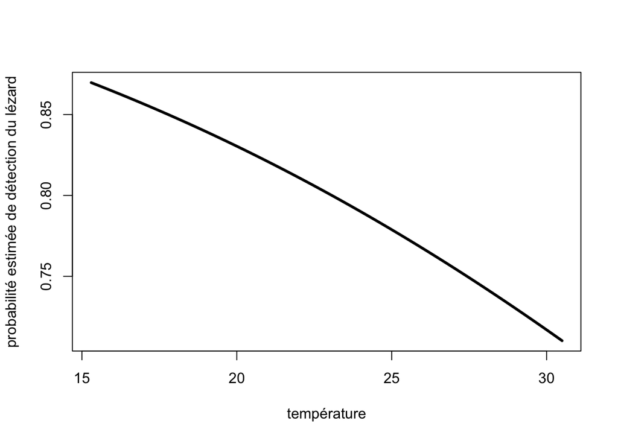

```r
plot(nd$temp,
     ppred[,1],
     type = "l",
     lwd = 3,
     xlab = "température",
     ylab = "probabilité estimée de détection du lézard")
```

Conditional occupancy.

```r
ranef(fm3)
```

```
##             Mean Mode 2.5% 97.5%
##  [1,] 1.00000000    1    1     1
##  [2,] 1.00000000    1    1     1
##  [3,] 1.00000000    1    1     1
##  [4,] 1.00000000    1    1     1
##  [5,] 1.00000000    1    1     1
##  [6,] 1.00000000    1    1     1
##  [7,] 1.00000000    1    1     1
##  [8,] 1.00000000    1    1     1
##  [9,] 0.03078700    0    0     1
## [10,] 1.00000000    1    1     1
## [11,] 0.02727979    0    0     1
## [12,] 1.00000000    1    1     1
## [13,] 1.00000000    1    1     1
## [14,] 1.00000000    1    1     1
```

[output cut: 56 more lines]

## 7. Modèle $(\psi, p_{\mbox{vent}})$

On crée un variable pour l’effet des vents.

```r
vent <- cbind(dat$vent_R1, dat$vent_R2, dat$vent_R3)
```

On refait le jeu de données.

```r
lezard <- unmarkedFrameOccu(y = cbind(dat$presence_R1, dat$presence_R2, dat$presence_R3),
                            obsCovs = list(vent = vent))
```

Données?

```r
summary(lezard)
```

```
## unmarkedFrame Object
##
## 70 sites
## Maximum number of observations per site: 3
## Mean number of observations per site: 3
## Sites with at least one detection: 53
##
## Tabulation of y observations:
##   0   1
##  82 128
##
## Observation-level covariates:
##       vent
##  Min.   :0.000
##  1st Qu.:2.500
##  Median :3.750
##  Mean   :3.941
##  3rd Qu.:5.000
##  Max.   :9.300
```

Ajuste modèle.

```r
fm4 <- occu(~ vent ~ 1, lezard)
```

Les estimations sont sur échelle logit.

```r
fm4
```

```
##
## Call:
## occu(formula = ~vent ~ 1, data = lezard)
##
## Occupancy:
##  Estimate    SE    z  P(>|z|)
##      1.17 0.286 4.09 4.36e-05
##
## Detection:
##             Estimate    SE     z P(>|z|)
## (Intercept)    0.404 0.467 0.866   0.387
## vent           0.268 0.124 2.170   0.030
##
## AIC: 234.4303
```

On back-transforme l’occupancy.

```r
backTransform(fm4, type = 'state')
```

```
## Backtransformed linear combination(s) of Occupancy estimate(s)
##
##  Estimate     SE LinComb (Intercept)
##     0.763 0.0517    1.17           1
##
## Transformation: logistic
```

```r
confint(backTransform(fm4, type='state'))
```

```
##      0.025     0.975
##  0.6474851 0.8491763
```

Et pour la détection.

```r
vent_partout <- c(dat$vent_R1, dat$vent_R2, dat$vent_R3)
nd <- data.frame(vent = seq(min(vent_partout), max(vent_partout), length = 50))
det_pred <- predict(fm4, type = 'det', newdata = nd)
```

Visualise.

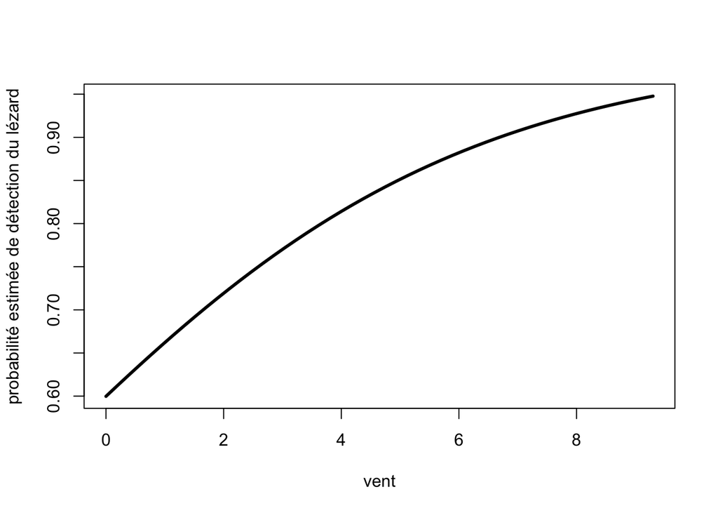

```r
plot(nd$vent,
     det_pred[,1],
     type = "l",
     lwd = 3,
     xlab = "vent",
     ylab = "probabilité estimée de détection du lézard")
```

Conditional occupancy.

```r
ranef(fm4)
```

```
##              Mean Mode 2.5% 97.5%
##  [1,] 1.000000000    1    1     1
##  [2,] 1.000000000    1    1     1
##  [3,] 1.000000000    1    1     1
##  [4,] 1.000000000    1    1     1
##  [5,] 1.000000000    1    1     1
##  [6,] 1.000000000    1    1     1
##  [7,] 1.000000000    1    1     1
##  [8,] 1.000000000    1    1     1
##  [9,] 0.056303334    0    0     1
## [10,] 1.000000000    1    1     1
## [11,] 0.004533178    0    0     0
## [12,] 1.000000000    1    1     1
## [13,] 1.000000000    1    1     1
## [14,] 1.000000000    1    1     1
```

[output cut: 56 more lines]

## 8. Modèle $(\psi, p_{\mbox{nuages}})$

On crée un variable pour l’effet des nuages

```r
nuage <- cbind(dat$nuage_R1, dat$nuage_R2, dat$nuage_R3)
```

On refait le jeu de données.

```r
lezard <- unmarkedFrameOccu(y = cbind(dat$presence_R1, dat$presence_R2, dat$presence_R3),
                            obsCovs = list(nuage = nuage))
```

Données?

```r
summary(lezard)
```

```
## unmarkedFrame Object
##
## 70 sites
## Maximum number of observations per site: 3
## Mean number of observations per site: 3
## Sites with at least one detection: 53
##
## Tabulation of y observations:
##   0   1
##  82 128
##
## Observation-level covariates:
##      nuage
##  Min.   :1.000
##  1st Qu.:1.000
##  Median :1.000
##  Mean   :1.957
##  3rd Qu.:3.000
##  Max.   :5.000
```

Ajuste modèle.

```r
fm5 <- occu(~ nuage ~ 1, lezard)
```

Les estimations sont sur échelle logit.

```r
fm5
```

```
##
## Call:
## occu(formula = ~nuage ~ 1, data = lezard)
##
## Occupancy:
##  Estimate    SE    z  P(>|z|)
##      1.17 0.286 4.09 4.37e-05
##
## Detection:
##             Estimate    SE    z P(>|z|)
## (Intercept)    0.859 0.377 2.28  0.0227
## nuage          0.284 0.186 1.53  0.1265
##
## AIC: 237.022
```

On back-transforme l’occupancy.

```r
backTransform(fm5, type = 'state')
```

```
## Backtransformed linear combination(s) of Occupancy estimate(s)
##
##  Estimate     SE LinComb (Intercept)
##     0.763 0.0517    1.17           1
##
## Transformation: logistic
```

```r
confint(backTransform(fm5, type='state'))
```

```
##      0.025     0.975
##  0.6476831 0.8495228
```

Et pour la détection.

```r
nuage_partout <- c(dat$nuage_R1, dat$nuage_R2, dat$nuage_R3)
nd <- data.frame(nuage = seq(min(nuage_partout), max(nuage_partout), length = 50))
det_pred <- predict(fm5, type = 'det', newdata = nd)
```

Visualise.

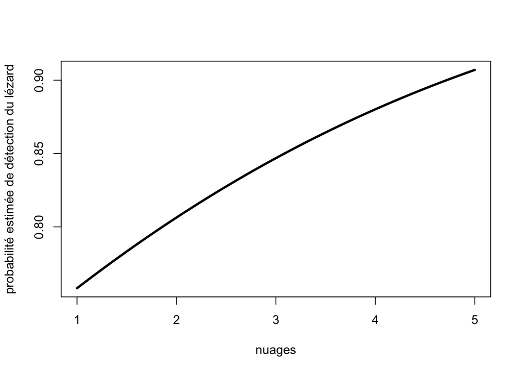

```r
plot(nd$nuage,
     det_pred[,1],
     type = "l",
     lwd = 3,
     xlab = "nuages",
     ylab = "probabilité estimée de détection du lézard")
```

Conditional occupancy.

```r
ranef(fm5)
```

```
##             Mean Mode 2.5% 97.5%
##  [1,] 1.00000000    1    1     1
##  [2,] 1.00000000    1    1     1
##  [3,] 1.00000000    1    1     1
##  [4,] 1.00000000    1    1     1
##  [5,] 1.00000000    1    1     1
##  [6,] 1.00000000    1    1     1
##  [7,] 1.00000000    1    1     1
##  [8,] 1.00000000    1    1     1
##  [9,] 0.03519201    0    0     1
## [10,] 1.00000000    1    1     1
## [11,] 0.01143612    0    0     0
## [12,] 1.00000000    1    1     1
## [13,] 1.00000000    1    1     1
## [14,] 1.00000000    1    1     1
```

[output cut: 56 more lines]

## 9. Modèle $(\psi_{lapins}, p_t)$

On a refait le jeu de données à chaque fois, mais on aurait pu tout mettre toutes les covariables en une fois.

Les covariables qui dépendent du temps.

```r
occ <- matrix(c('occ 1','occ 2','occ 3'),
              nrow = 70, # nrow(lezard@y),
              ncol = 3, #ncol(lezard),
              byrow = TRUE)

temp <- cbind(dat$temp_R1, dat$temp_R2, dat$temp_R3)
vent <- cbind(dat$vent_R1, dat$vent_R2, dat$vent_R3)
nuage <- cbind(dat$nuage_R1, dat$nuage_R2, dat$nuage_R3)
```

La covariable qui dépend du site.

```r
site.covs <- data.frame(lapin = dat$nb_terriers_lapins)
site.covs
```

```
##    lapin
## 1      0
## 2      5
## 3      1
## 4      2
## 5      5
## 6     10
## 7      0
## 8      0
## 9      0
## 10     5
## 11     0
## 12    20
## 13     0
## 14     0
```

[output cut: 56 more lines]

On refait le jeu de données.

```r
lezard <- unmarkedFrameOccu(y = cbind(dat$presence_R1, dat$presence_R2, dat$presence_R3),
                            obsCovs = list(temp = temp,
                                           vent = vent,
                                           nuage = nuage,
                                           occ = occ),
                            siteCovs = site.covs)
```

Données?

```r
summary(lezard)
```

```
## unmarkedFrame Object
##
## 70 sites
## Maximum number of observations per site: 3
## Mean number of observations per site: 3
## Sites with at least one detection: 53
##
## Tabulation of y observations:
##   0   1
##  82 128
##
## Site-level covariates:
##      lapin
##  Min.   : 0.000
##  1st Qu.: 0.000
##  Median : 0.000
##  Mean   : 1.643
##  3rd Qu.: 1.000
##  Max.   :20.000
##
## Observation-level covariates:
##       temp            vent           nuage          occ
##  Min.   :15.30   Min.   :0.000   Min.   :1.000   occ 1:70
##  1st Qu.:20.43   1st Qu.:2.500   1st Qu.:1.000   occ 2:70
##  Median :23.20   Median :3.750   Median :1.000   occ 3:70
##  Mean   :22.74   Mean   :3.941   Mean   :1.957
##  3rd Qu.:24.80   3rd Qu.:5.000   3rd Qu.:3.000
##  Max.   :30.50   Max.   :9.300   Max.   :5.000
```

Ajuste modèle.

```r
fm6 <- occu(~ occ ~ lapin, lezard)
```

Les estimations sont sur échelle logit.

```r
fm6
```

```
##
## Call:
## occu(formula = ~occ ~ lapin, data = lezard)
##
## Occupancy:
##             Estimate    SE    z P(>|z|)
## (Intercept)    0.817 0.311 2.63 0.00857
## lapin          1.095 0.887 1.24 0.21675
##
## Detection:
##             Estimate    SE    z  P(>|z|)
## (Intercept)    0.365 0.277 1.32 0.187323
## occocc 2       1.510 0.488 3.09 0.001984
## occocc 3       1.876 0.542 3.46 0.000535
##
## AIC: 223.3935
```

On back-transforme la détection.

```r
nd <- data.frame(occ = c('occ 1','occ 2','occ 3'))
predict(fm6, type = 'det', newdata = nd)
```

```
##   Predicted         SE     lower     upper
## 1 0.5903143 0.06699593 0.4556944 0.7126354
## 2 0.8670254 0.04674690 0.7465347 0.9352091
## 3 0.9039182 0.04081258 0.7892671 0.9594010
```

Et pour l’occupancy.

```r
nd <- data.frame(lapin = seq(min(dat$nb_terriers_lapins),
                             max(dat$nb_terriers_lapins),
                             length = 50))
occ_pred <- predict(fm6, type = 'state', newdata = nd)
```

Visualise.

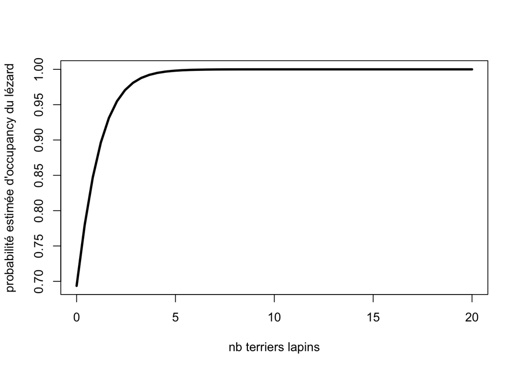

```r
plot(nd$lapin,
     occ_pred[,1],
     type = "l",
     lwd = 3,
     xlab = "nb terriers lapins",
     ylab = "probabilité estimée d'occupancy du lézard")
```

Conditional occupancy.

```r
ranef(fm6)
```

```
##             Mean Mode 2.5% 97.5%
##  [1,] 1.00000000    1    1     1
##  [2,] 1.00000000    1    1     1
##  [3,] 1.00000000    1    1     1
##  [4,] 1.00000000    1    1     1
##  [5,] 1.00000000    1    1     1
##  [6,] 1.00000000    1    1     1
##  [7,] 1.00000000    1    1     1
##  [8,] 1.00000000    1    1     1
##  [9,] 0.01170828    0    0     0
## [10,] 1.00000000    1    1     1
## [11,] 0.01170828    0    0     0
## [12,] 1.00000000    1    1     1
## [13,] 1.00000000    1    1     1
## [14,] 1.00000000    1    1     1
```

[output cut: 56 more lines]

## 10. Sélection de modèles

On fait tourner les modèles avec le même jeu de données.

```r
fm <- occu(~ 1 ~ 1, lezard)
fm1 <- occu(~ occ ~ 1, lezard)
fm2 <- occu(~ 1 ~ lapin, lezard)
fm3 <- occu(~ temp ~ 1, lezard)
fm4 <- occu(~ vent ~ 1, lezard)
fm5 <- occu(~ nuage ~ 1, lezard)
fm6 <- occu(~ occ ~ lapin, lezard)
```

On les rassemble.

```r
fmList <- fitList('{psi, p}' = fm,
                  '{psi, p(survey)}' = fm1,
                  '{psi(terrier), p}' = fm2,
                  '{psi, p(temp)}' = fm3,
                  '{psi, p(vent)}' = fm4,
                  '{psi, p(nuage)}' = fm5,
                  '{psi(terrier), p(survey)}' = fm6)
```

Les AIC.

```r
modSel(fmList)
```

```
##                           nPars    AIC delta   AICwt cumltvWt
## {psi, p(survey)}              4 222.21  0.00 0.64237     0.64
## {psi(terrier), p(survey)}     5 223.39  1.19 0.35505     1.00
## {psi, p(vent)}                3 234.43 12.22 0.00142     1.00
## {psi, p(nuage)}               3 237.02 14.81 0.00039     1.00
## {psi(terrier), p}             3 237.53 15.32 0.00030     1.00
## {psi, p}                      2 237.67 15.46 0.00028     1.00
## {psi, p(temp)}                3 238.59 16.38 0.00018     1.00
```

Extract coefficients and standard errors

```r
coef(fmList)
```

```
##                            psi(Int)    p(Int) p(occocc 2) p(occocc 3)
## {psi, p}                  1.1713346 1.3765499          NA          NA
## {psi, p(survey)}          1.1521988 0.4119290    1.614644    2.046152
## {psi(terrier), p}         0.8331349 1.2906682          NA          NA
## {psi, p(temp)}            1.1670606 2.9072854          NA          NA
## {psi, p(vent)}            1.1680789 0.4044432          NA          NA
## {psi, p(nuage)}           1.1698669 0.8590802          NA          NA
## {psi(terrier), p(survey)} 0.8168358 0.3652647    1.509645    1.876275
##                           psi(lapin)     p(temp)   p(vent)  p(nuage)
## {psi, p}                          NA          NA        NA        NA
## {psi, p(survey)}                  NA          NA        NA        NA
## {psi(terrier), p}           1.112579          NA        NA        NA
## {psi, p(temp)}                    NA -0.06593141        NA        NA
## {psi, p(vent)}                    NA          NA 0.2681045        NA
## {psi, p(nuage)}                   NA          NA        NA 0.2837187
## {psi(terrier), p(survey)}   1.095185          NA        NA        NA
```

```r
SE(fmList)
```

```
##                            psi(Int)    p(Int) p(occocc 2) p(occocc 3)
## {psi, p}                  0.2866169 0.2073071          NA          NA
## {psi, p(survey)}          0.2821304 0.2808942   0.5137252   0.5873551
## {psi(terrier), p}         0.3142727 0.1986067          NA          NA
## {psi, p(temp)}            0.2855257 1.5146917          NA          NA
## {psi, p(vent)}            0.2857584 0.4670586          NA          NA
## {psi, p(nuage)}           0.2862278 0.3770512          NA          NA
## {psi(terrier), p(survey)} 0.3107411 0.2770220   0.4881479   0.5418638
##                           psi(lapin)    p(temp)   p(vent)  p(nuage)
## {psi, p}                          NA         NA        NA        NA
## {psi, p(survey)}                  NA         NA        NA        NA
## {psi(terrier), p}          0.8933203         NA        NA        NA
## {psi, p(temp)}                    NA 0.06408379        NA        NA
## {psi, p(vent)}                    NA         NA 0.1235454        NA
## {psi, p(nuage)}                   NA         NA        NA 0.1856837
## {psi(terrier), p(survey)}  0.8866299         NA        NA        NA
```

Model-averaged prediction

```r
predict(fmList, type="state")
```

```
##    Predicted         SE     lower     upper
## 1  0.7363432 0.06446005 0.6121833 0.8320198
## 2  0.8445788 0.11851815 0.4489962 0.9008652
## 3  0.7994829 0.08498789 0.6116170 0.8916210
## 4  0.8284979 0.10740126 0.5598215 0.9002769
## 5  0.8445788 0.11851815 0.4489962 0.9008652
## 6  0.8452321 0.11922432 0.4175799 0.9008654
## 7  0.7363432 0.06446005 0.6121833 0.8320198
## 8  0.7363432 0.06446005 0.6121833 0.8320198
## 9  0.7363432 0.06446005 0.6121833 0.8320198
## 10 0.8445788 0.11851815 0.4489962 0.9008652
## 11 0.7363432 0.06446005 0.6121833 0.8320198
## 12 0.8452348 0.11922760 0.4161149 0.9008654
## 13 0.7363432 0.06446005 0.6121833 0.8320198
## 14 0.7363432 0.06446005 0.6121833 0.8320198
```

[output cut: 56 more lines]

# Partie 2

On lit les données lézard ocelés.

```r
dat <- read.csv2("dat/lezard-ocelle-oleron-2007-pa.csv")
```

Les covariables qui dépendent du temps.

```r
occ <- matrix(c('occ 1','occ 2','occ 3'),
              nrow = 70, # nrow(lezard@y),
              ncol = 3, #ncol(lezard),
              byrow = TRUE)

temp <- cbind(dat$temp_R1, dat$temp_R2, dat$temp_R3)
vent <- cbind(dat$vent_R1, dat$vent_R2, dat$vent_R3)
nuage <- cbind(dat$nuage_R1, dat$nuage_R2, dat$nuage_R3)
```

La covariable qui dépend du site.

```r
site.covs <- data.frame(lapin = dat$nb_terriers_lapins)
site.covs
```

```
##    lapin
## 1      0
## 2      5
## 3      1
## 4      2
## 5      5
## 6     10
## 7      0
## 8      0
## 9      0
## 10     5
## 11     0
## 12    20
## 13     0
## 14     0
```

[output cut: 56 more lines]

On refait le jeu de données.

```r
lezard <- unmarkedFramePCount(y = cbind(dat$Abond_R1, dat$Abond_R2, dat$Abond_R3),
                            obsCovs = list(temp = temp,
                                           vent = vent,
                                           nuage = nuage,
                                           occ = occ),
                            siteCovs = site.covs)
```

Données?

```r
summary(lezard)
```

```
## unmarkedFrame Object
##
## 70 sites
## Maximum number of observations per site: 3
## Mean number of observations per site: 3
## Sites with at least one detection: 44
##
## Tabulation of y observations:
##   0   1   2   3   5
## 124  65  18   2   1
##
## Site-level covariates:
##      lapin
##  Min.   : 0.000
##  1st Qu.: 0.000
##  Median : 0.000
##  Mean   : 1.643
##  3rd Qu.: 1.000
##  Max.   :20.000
##
## Observation-level covariates:
##       temp            vent           nuage          occ
##  Min.   :15.30   Min.   :0.000   Min.   :1.000   occ 1:70
##  1st Qu.:20.43   1st Qu.:2.500   1st Qu.:1.000   occ 2:70
##  Median :23.20   Median :3.750   Median :1.000   occ 3:70
##  Mean   :22.74   Mean   :3.941   Mean   :1.957
##  3rd Qu.:24.80   3rd Qu.:5.000   3rd Qu.:3.000
##  Max.   :30.50   Max.   :9.300   Max.   :5.000
```

Ajuste modèle.

```r
fm <- pcount(~ 1 ~ 1, lezard, K = 100) # detection, then abundance
```

```r
fm
```

```
##
## Call:
## pcount(formula = ~1 ~ 1, data = lezard, K = 100)
##
## Abundance:
##  Estimate    SE    z P(>|z|)
##     0.392 0.207 1.89  0.0585
##
## Detection:
##  Estimate    SE     z P(>|z|)
##    -0.573 0.308 -1.86   0.063
##
## AIC: 388.2797
```

On back-transforme la détection.

```r
names(fm)
```

```
## [1] "state" "det"
```

```r
backTransform(fm, "state")
```

```
## Backtransformed linear combination(s) of Abundance estimate(s)
##
##  Estimate    SE LinComb (Intercept)
##      1.48 0.306   0.392           1
##
## Transformation: exp
```

```r
backTransform(fm, "det")
```

```
## Backtransformed linear combination(s) of Detection estimate(s)
##
##  Estimate     SE LinComb (Intercept)
##      0.36 0.0711  -0.573           1
##
## Transformation: logistic
```

Conditional occupancy.

```r
ranef(fm)
```

```
##            Mean Mode 2.5% 97.5%
##  [1,] 2.3870908    2    2     4
##  [2,] 5.6583727    5    5     8
##  [3,] 3.5013750    3    3     5
##  [4,] 2.5492509    2    2     4
##  [5,] 3.1355654    3    2     5
##  [6,] 3.6408386    3    3     5
##  [7,] 2.7543916    2    2     5
##  [8,] 1.6661575    1    1     3
##  [9,] 0.3870908    0    0     2
## [10,] 2.0192330    2    1     4
## [11,] 0.3870908    0    0     2
## [12,] 2.0192330    2    1     4
## [13,] 0.3870908    0    0     2
## [14,] 1.3870908    1    1     3
```

[output cut: 56 more lines]

On fait tourner qqs modèles avec le même jeu de données.

```r
fm <- pcount(~ 1 ~ 1, lezard, K = 100)
fm1 <- pcount(~ occ ~ 1, lezard, K = 100)
fm2 <- pcount(~ 1 ~ lapin, lezard, K = 100)
fm3 <- pcount(~ temp ~ 1, lezard, K = 100)
fm4 <- pcount(~ occ ~ lapin, lezard, K = 100)
```

On les rassemble.

```r
fmList <- fitList('{lambda, r}' = fm,
                  '{lambda, p(survey)}' = fm1,
                  '{lambda(terrier), p}' = fm2,
                  '{lambda, p(temp)}' = fm3,
                  '{lambda(terrier), p(survey)}' = fm4)
```

Les AIC.

```r
modSel(fmList)
```

```
##                              nPars    AIC delta   AICwt cumltvWt
## {lambda(terrier), p(survey)}     5 370.70  0.00 8.2e-01     0.82
## {lambda, p(survey)}              4 373.73  3.03 1.8e-01     1.00
## {lambda(terrier), p}             3 384.92 14.21 6.7e-04     1.00
## {lambda, r}                      2 388.28 17.58 1.2e-04     1.00
## {lambda, p(temp)}                3 390.22 19.52 4.7e-05     1.00
```

On back-transforme la détection.

```r
nd <- data.frame(occ = c('occ 1','occ 2','occ 3'))
predict(fm4, type = 'det', newdata = nd)
```

```
##   Predicted         SE     lower     upper
## 1 0.2256764 0.05521334 0.1356192 0.3512355
## 2 0.5050785 0.09246544 0.3307763 0.6781549
## 3 0.4728425 0.08841737 0.3091775 0.6425602
```

```r
nd <- data.frame(lapin = seq(min(dat$nb_terriers_lapins),
                             max(dat$nb_terriers_lapins),
                             length = 50))
N_pred <- predict(fm4, type = 'state', newdata = nd)
```

Visualise.

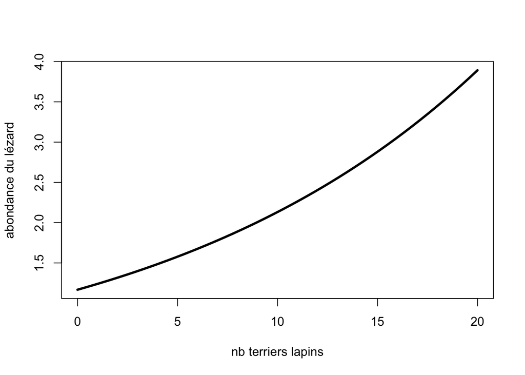

```r
plot(nd$lapin,
     N_pred[,1],
     type = "l",
     lwd = 3,
     xlab = "nb terriers lapins",
     ylab = "abondance du lézard")
```

# Partie 3

On lit les données.

```r
dat <- readxl::read_xlsx("dat/dynoccupancy.xlsx")
dat
```

```
## # A tibble: 250 x 30
##    `Session 1-1` `Session 1-2` `Session 1-3` `Session 2-1` `Session 2-2`
##            <dbl>         <dbl>         <dbl>         <dbl>         <dbl>
##  1             0             0             0             0             1
##  2             0             0             0             0             0
##  3             0             0             0             0             0
##  4             1             0             0             1             0
##  5             0             0             0             0             0
##  6             0             0             0             0             0
##  7             0             0             0             0             0
##  8             0             0             1             0             0
##  9             1             1             0             0             1
## 10             0             0             0             0             0
## # … with 240 more rows, and 25 more variables: `Session 2-3` <dbl>, `Session
## #   3-1` <dbl>, `Session 3-2` <dbl>, `Session 3-3` <dbl>, `Session 4-1` <dbl>,
## #   `Session 4-2` <dbl>, `Session 4-3` <dbl>, `Session 5-1` <dbl>, `Session
## #   5-2` <dbl>, `Session 5-3` <dbl>, `Session 6-1` <dbl>, `Session 6-2` <dbl>,
## #   `Session 6-3` <dbl>, `Session 7-1` <dbl>, `Session 7-2` <dbl>, `Session
## #   7-3` <dbl>, `Session 8-1` <dbl>, `Session 8-2` <dbl>, `Session 8-3` <dbl>,
## #   `Session 9-1` <dbl>, `Session 9-2` <dbl>, `Session 9-3` <dbl>, `Session
## #   10-1` <dbl>, `Session 10-2` <dbl>, `Session 10-3` <dbl>
```

Des modèles.

```r
yearly.site.covs <- list(
   year = matrix(paste0("year", 1:10),
                 nrow = 250,
                 ncol = 10,
                 byrow = TRUE))
head(yearly.site.covs)
```

```
## $year
##        [,1]    [,2]    [,3]    [,4]    [,5]    [,6]    [,7]    [,8]    [,9]
##   [1,] "year1" "year2" "year3" "year4" "year5" "year6" "year7" "year8" "year9"
##   [2,] "year1" "year2" "year3" "year4" "year5" "year6" "year7" "year8" "year9"
##   [3,] "year1" "year2" "year3" "year4" "year5" "year6" "year7" "year8" "year9"
##   [4,] "year1" "year2" "year3" "year4" "year5" "year6" "year7" "year8" "year9"
##   [5,] "year1" "year2" "year3" "year4" "year5" "year6" "year7" "year8" "year9"
##   [6,] "year1" "year2" "year3" "year4" "year5" "year6" "year7" "year8" "year9"
##   [7,] "year1" "year2" "year3" "year4" "year5" "year6" "year7" "year8" "year9"
##   [8,] "year1" "year2" "year3" "year4" "year5" "year6" "year7" "year8" "year9"
##   [9,] "year1" "year2" "year3" "year4" "year5" "year6" "year7" "year8" "year9"
##  [10,] "year1" "year2" "year3" "year4" "year5" "year6" "year7" "year8" "year9"
##  [11,] "year1" "year2" "year3" "year4" "year5" "year6" "year7" "year8" "year9"
##  [12,] "year1" "year2" "year3" "year4" "year5" "year6" "year7" "year8" "year9"
##  [13,] "year1" "year2" "year3" "year4" "year5" "year6" "year7" "year8" "year9"
```

[output cut: 488 more lines]

```r
umf <- unmarkedMultFrame(y = dat,
                         yearlySiteCovs = yearly.site.covs,
                         numPrimary = 10)
umf                                # look at data
```

```
## Data frame representation of unmarkedFrame object.
##     y.1 y.2 y.3 y.4 y.5 y.6 y.7 y.8 y.9 y.10 y.11 y.12 y.13 y.14 y.15 y.16 y.17
## 1     0   0   0   0   1   1   1   0   0    0    0    0    0    0    0    0    0
## 2     0   0   0   0   0   0   0   0   0    0    0    0    0    0    0    0    0
## 3     0   0   0   0   0   0   1   1   1    0    0    1    0    0    0    0    0
## 4     1   0   0   1   0   1   1   1   0    0    0    0    0    0    0    0    0
## 5     0   0   0   0   0   0   0   0   0    0    0    0    0    0    0    0    0
## 6     0   0   0   0   0   0   0   0   1    0    0    0    0    0    0    0    0
## 7     0   0   0   0   0   0   0   0   0    0    0    0    0    0    0    0    0
## 8     0   0   1   0   0   0   0   1   1    1    0    1    0    0    0    0    0
## 9     1   1   0   0   1   0   0   0   0    0    0    0    0    0    0    0    0
## 10    0   0   0   0   0   0   0   0   0    0    0    0    0    0    0    0    0
## 11    1   0   0   0   0   0   0   0   0    0    0    0    0    0    0    0    0
## 12    0   0   0   1   1   0   1   1   0    0    0    0    0    0    0    1    1
## 13    0   0   0   0   0   0   0   0   0    0    0    1    0    1    0    0    0
```

[output cut: 1241 more lines]

```r
summary(umf)                       # summarize
```

```
## unmarkedFrame Object
##
## 250 sites
## Maximum number of observations per site: 30
## Mean number of observations per site: 30
## Number of primary survey periods: 10
## Number of secondary survey periods: 3
## Sites with at least one detection: 195
##
## Tabulation of y observations:
##    0    1
## 6430 1070
##
## Yearly-site-level covariates:
##       year
##  year1  : 250
##  year10 : 250
##  year2  : 250
##  year3  : 250
##  year4  : 250
##  year5  : 250
##  (Other):1000
```

```r
fm <- colext(~1, ~1, ~1, ~1, umf)  # fit constant param model
                                   # psi, gam (colonization), eps (extinction), det
fm
```

```
##
## Call:
## colext(psiformula = ~1, gammaformula = ~1, epsilonformula = ~1,
##     pformula = ~1, data = umf)
##
## Initial:
##  Estimate    SE     z  P(>|z|)
##    -0.813 0.158 -5.16 2.46e-07
##
## Colonization:
##  Estimate     SE   z   P(>|z|)
##     -1.77 0.0807 -22 2.75e-107
##
## Extinction:
##  Estimate    SE     z  P(>|z|)
##     -0.59 0.102 -5.79 7.04e-09
##
## Detection:
##  Estimate     SE     z P(>|z|)
##   -0.0837 0.0562 -1.49   0.137
##
## AIC: 4972.597
```

On back-transforme l’occupancy.

```r
names(fm)
```

```
## [1] "psi" "col" "ext" "det"
```

```r
backTransform(fm, type = 'psi')
```

```
## Backtransformed linear combination(s) of Initial estimate(s)
##
##  Estimate     SE LinComb (Intercept)
##     0.307 0.0335  -0.813           1
##
## Transformation: logistic
```

```r
confint(backTransform(fm, type='psi'))
```

```
##      0.025     0.975
##  0.2457313 0.3765804
```

```r
backTransform(fm, type = 'col')
```

```
## Backtransformed linear combination(s) of Colonization estimate(s)
##
##  Estimate   SE LinComb (Intercept)
##     0.145 0.01   -1.77           1
##
## Transformation: logistic
```

```r
confint(backTransform(fm, type='col'))
```

```
##      0.025     0.975
##  0.1264488 0.1656803
```

```r
backTransform(fm, type = 'ext')
```

```
## Backtransformed linear combination(s) of Extinction estimate(s)
##
##  Estimate     SE LinComb (Intercept)
##     0.357 0.0234   -0.59           1
##
## Transformation: logistic
```

```r
confint(backTransform(fm, type='ext'))
```

```
##      0.025     0.975
##  0.3121051 0.4035828
```

```r
backTransform(fm, type = 'det')
```

```
## Backtransformed linear combination(s) of Detection estimate(s)
##
##  Estimate    SE LinComb (Intercept)
##     0.479 0.014 -0.0837           1
##
## Transformation: logistic
```

```r
confint(backTransform(fm, type='det'))
```

```
##      0.025     0.975
##  0.4516614 0.5066307
```

Conditional occupancy.

```r
ranef(fm)
```

```
## , , Year1
##
##              Mean Mode 2.5% 97.5%
##   [1,] 0.05900634    0    0     1
##   [2,] 0.05900634    0    0     1
##   [3,] 0.05900634    0    0     1
##   [4,] 1.00000000    1    1     1
##   [5,] 0.05900634    0    0     1
##   [6,] 0.05900634    0    0     1
##   [7,] 0.05900634    0    0     1
##   [8,] 1.00000000    1    1     1
##   [9,] 1.00000000    1    1     1
##  [10,] 0.05900634    0    0     1
##  [11,] 1.00000000    1    1     1
##  [12,] 0.05900634    0    0     1
```

[output cut: 2524 more lines]

On ajuste plusiers modèles.

```r
fm <- colext(~1, ~1, ~1, ~1, umf)
fm1 <- colext(~1, ~year, ~1, ~1, umf)
fm2 <- colext(~1, ~1, ~year, ~1, umf)
fm3 <- colext(~1, ~year, ~year, ~1, umf)
```

On les rassemble.

```r
fmList <- fitList('{psi, col, ext, det}' = fm,
                  '{psi, col(year), ext, det}' = fm1,
                  '{psi, col, ext(year), det}' = fm2,
                  '{psi, col(year), ext(year), det}' = fm3)
```

Les AIC.

```r
modSel(fmList)
```

```
##                                  nPars     AIC  delta   AICwt cumltvWt
## {psi, col(year), ext(year), det}    20 4856.93   0.00 1.0e+00     1.00
## {psi, col, ext(year), det}          12 4887.51  30.58 2.3e-07     1.00
## {psi, col(year), ext, det}          12 4933.79  76.86 2.0e-17     1.00
## {psi, col, ext, det}                 4 4972.60 115.67 7.6e-26     1.00
```

On crée un variable pour l’effet du temps, et on prédit col et ext.

```r
nd <- data.frame(year = paste0("year", 1:9))
col_pred <- predict(fm3, type = 'col', newdata = nd)
ext_pred <- predict(fm3, type = 'ext', newdata = nd)
```

Visualise.

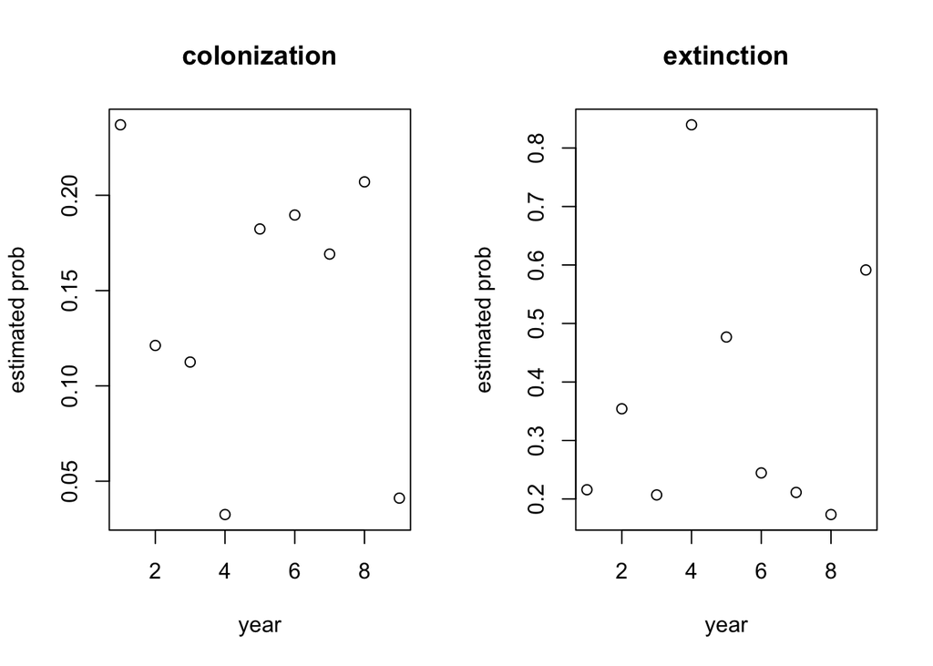

```r
par(mfrow = c(1,2))
plot(1:9, col_pred[,1],
     xlab = "year",
     ylab = "estimated prob",
     main = "colonization")
plot(1:9, ext_pred[,1],
     xlab = "year",
     ylab = "estimated prob",
     main = "extinction")
```

La même chose avec intervalle de confiance.

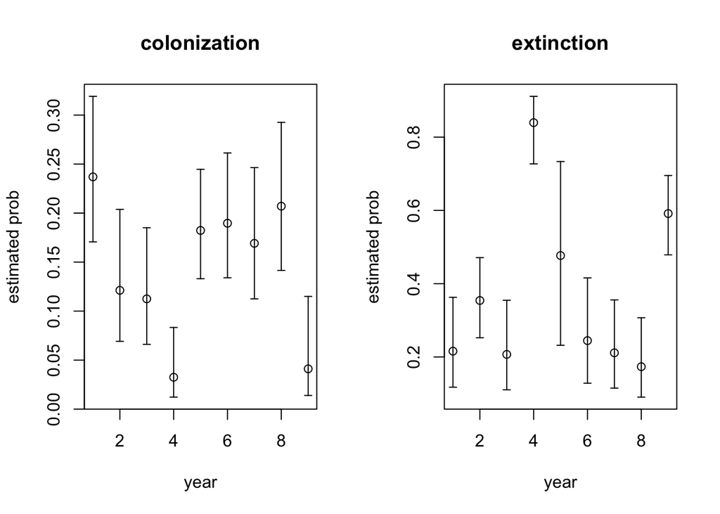

```r
library(plotrix)
par(mfrow = c(1,2))
plotCI(1:9, col_pred[,1],
       li = col_pred[,3],
       ui = col_pred[,4],
       xlab = "year",
       ylab = "estimated prob",
       main = "colonization")
plotCI(1:9, ext_pred[,1],
       li = ext_pred[,3],
       ui = ext_pred[,4],
       xlab = "year",
       ylab = "estimated prob",
       main = "extinction")
```